# Deep Learning for TS

### Overview

The goal of this section is to apply deep learning algorithms to the oil price monthly data in order to make predictions of what the price of oil will be in the future.

The libraries that will be used in this section are in the following list:

**Libraries**

```python
# Import Data
import pandas as pd

# Plotting
import numpy as np
import matplotlib.pyplot as plt
import seaborn as sns

# Keras
from tensorflow import keras
from tensorflow.keras import layers
from tensorflow.keras import initializers
from tensorflow.keras import regularizers
from keras.layers import Dense, SimpleRNN, LSTM ,GRU
```

### Data

For this analysis we will use the monthly adjusted oil price for the last 22 years which we can observe in the next table. The will be later transformed to be saved as a np.array() with a similar format to the time series object used in past sections.

```
           date  adjusted
0    2000-08-31  1.032761
1    2000-09-30  0.974075
2    2000-10-31  1.019969
3    2000-11-30  1.054602
4    2000-12-31  0.842991
..          ...       ...
264  2022-08-31  2.794072
265  2022-09-30  2.480187
266  2022-10-31  2.699844
267  2022-11-30  2.513261
268  2022-12-30  2.504212

[269 rows x 2 columns]
```

```
CHECK NA:
 t    0
y    0
dtype: int64
```

### Visualize Data

When we plot the raw data, as we evaluated in previous sections, we can observe there is no clear trend over all the years and there is a lot of fluctuation.

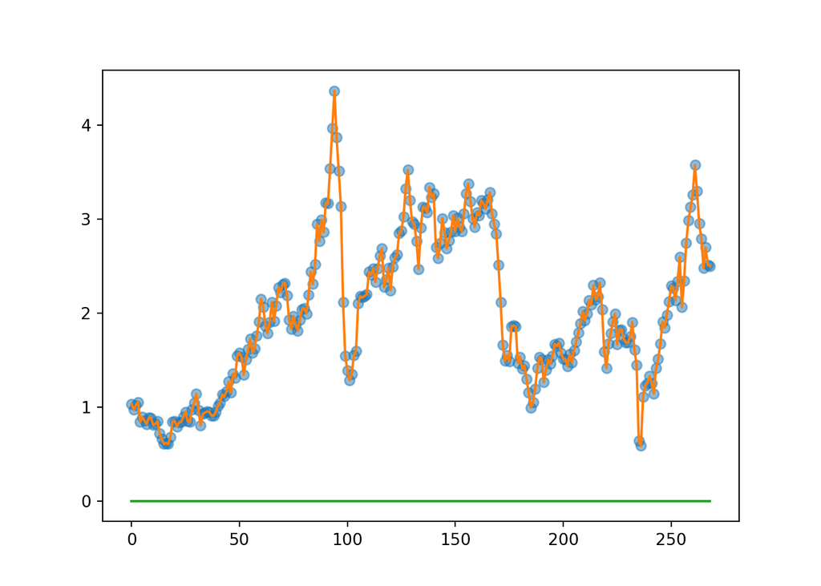

### Normalize Data

In order to apply the data points to the deep learning algorithms we transformed the data to be normalized. For this procedure we used the mean and standard deviation of the points. After normalizing the data, the output values are between -3 and 3.

We plotted the transformed data and we can observe that the shape of the time series is very similar.

```
(1,) (1,)
```

```
(269, 1)
```

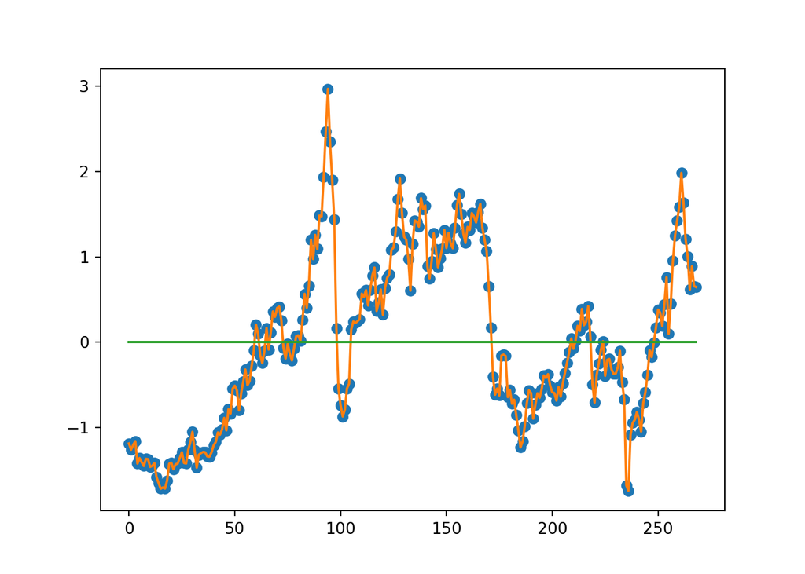

### Split Data

The next step is to split the data into train and validation sets. To perform this split we use an 80% of the data points for the train set and a 20% of the data points for the validation set.

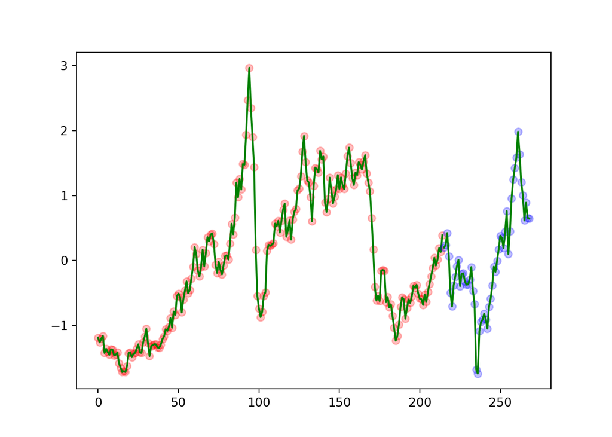

### Form Mini Batches

For this approach we will use mini batches. This allows to look at an especific number of data points at the same time for every iteration. In this case, considering the large amount of data points, we selected a lookback value of 25.

**{python}**

```python
# training
L=25; S=1; D=1
Xt,Yt=form_arrays(xt,lookback=L,delay=D,step=S,feature_columns=feature_columns,target_columns=target_columns,unique=False,verbose=False)

# validation
Xv,Yv=form_arrays(xv,lookback=L,delay=D,step=S,feature_columns=feature_columns,target_columns=target_columns,unique=False,verbose=False)
```

```
training: (189, 26, 1) (189, 1)
```

```
validation: (28, 26, 1) (28, 1)
```

### Keras - RNN

The first model we fitted is RNN using the functions from Keras in the tensorflow package.

In the **Training and validation loss** plot we can observe that the training errors / loss reduces when the number of Epochs increases. In the case of the validation errors, they fluctuate a lot. This suggests that the model is not performing correctly and is probably overfitting.

We can compare the Validation data plot and the traning data plot and clearly see that the training values correlate better with the line, while the validation values do not.

```
(189, 26, 1) --> (189, 1)
```

```
(28, 26, 1) --> (28, 1)
```

```
Model: "sequential"
_________________________________________________________________
 Layer (type)                Output Shape              Param #
=================================================================
 simple_rnn (SimpleRNN)      (None, 32)                1088

 dense (Dense)               (None, 1)                 33

=================================================================
Total params: 1121 (4.38 KB)
Trainable params: 1121 (4.38 KB)
Non-trainable params: 0 (0.00 Byte)
_________________________________________________________________
None
```

```
WARNING:absl:At this time, the v2.11+ optimizer `tf.keras.optimizers.RMSprop` runs slowly on M1/M2 Macs, please use the legacy Keras optimizer instead, located at `tf.keras.optimizers.legacy.RMSprop`.
```

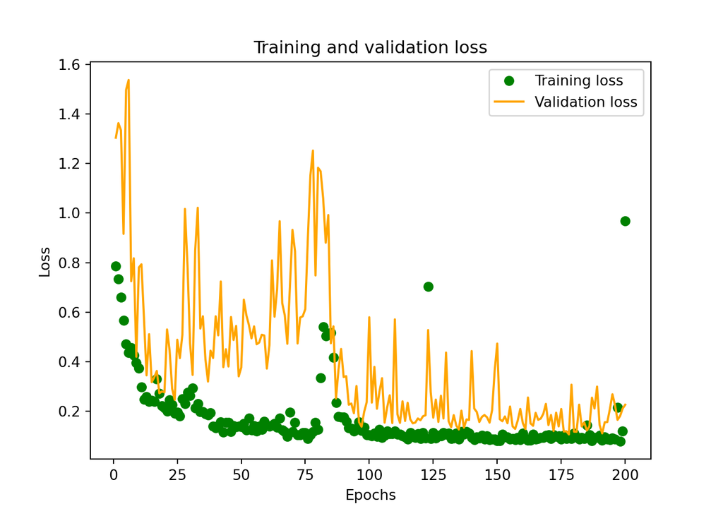

```
---------- Regression report ----------
TRAINING:
 RMSE: 0.28375985593368
 MSE: 0.08051965583950285
 MAE: 0.19784153141700228
VALIDATION:
 RMSE: 0.47555828674769596
 MSE: 0.2261556840944038
 MAE: 0.3744376816209892
```

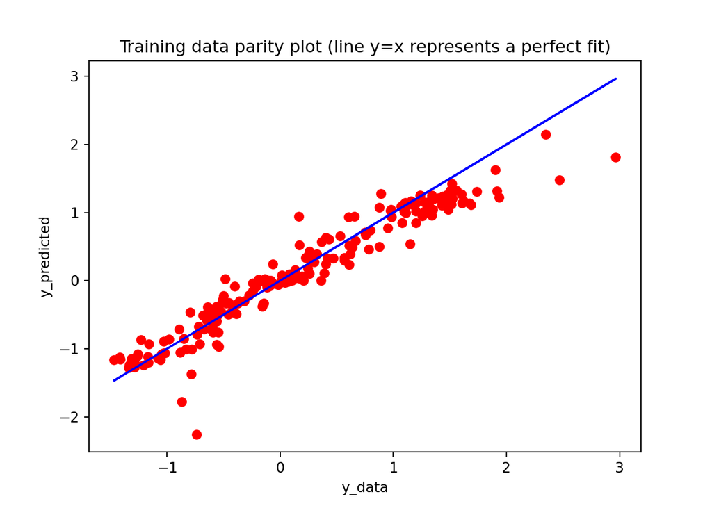

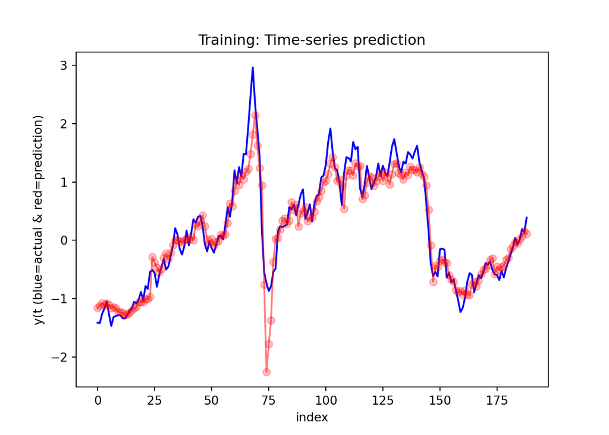

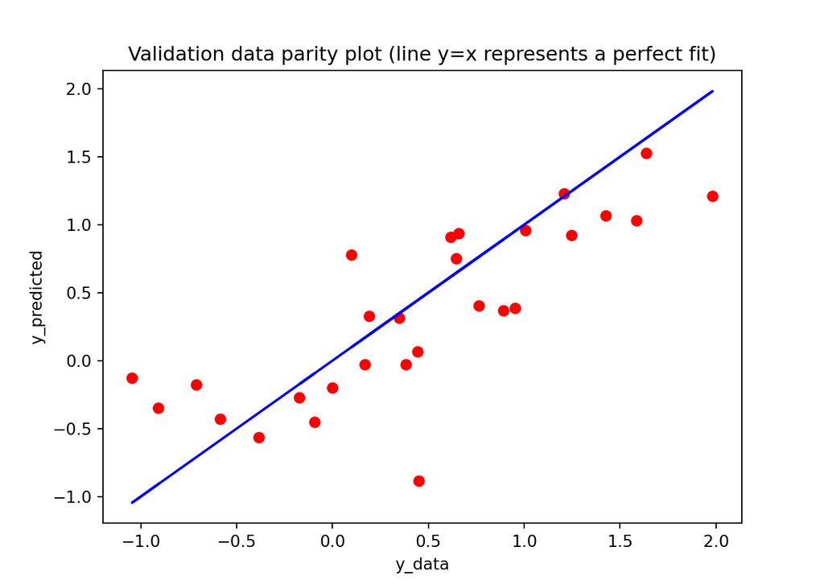

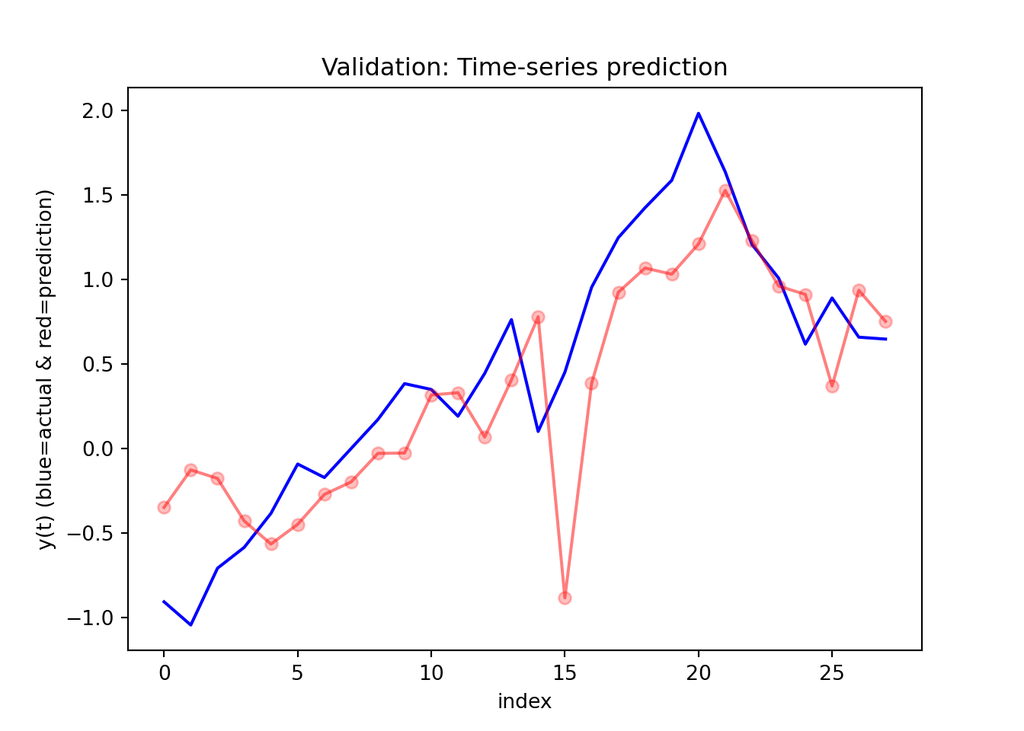

### Keras - GRU

In the case of the GRU model created from the Keras function from the Tensorflow package, we obtained very different results for each analysis.

```
(189, 26, 1) --> (189, 1)
```

```
(28, 26, 1) --> (28, 1)
```

```
Model: "sequential_1"
_________________________________________________________________
 Layer (type)                Output Shape              Param #
=================================================================
 gru (GRU)                   (None, 32)                3360

 dense_1 (Dense)             (None, 1)                 33

=================================================================
Total params: 3393 (13.25 KB)
Trainable params: 3393 (13.25 KB)
Non-trainable params: 0 (0.00 Byte)
_________________________________________________________________
None
```

```
WARNING:absl:At this time, the v2.11+ optimizer `tf.keras.optimizers.RMSprop` runs slowly on M1/M2 Macs, please use the legacy Keras optimizer instead, located at `tf.keras.optimizers.legacy.RMSprop`.
```

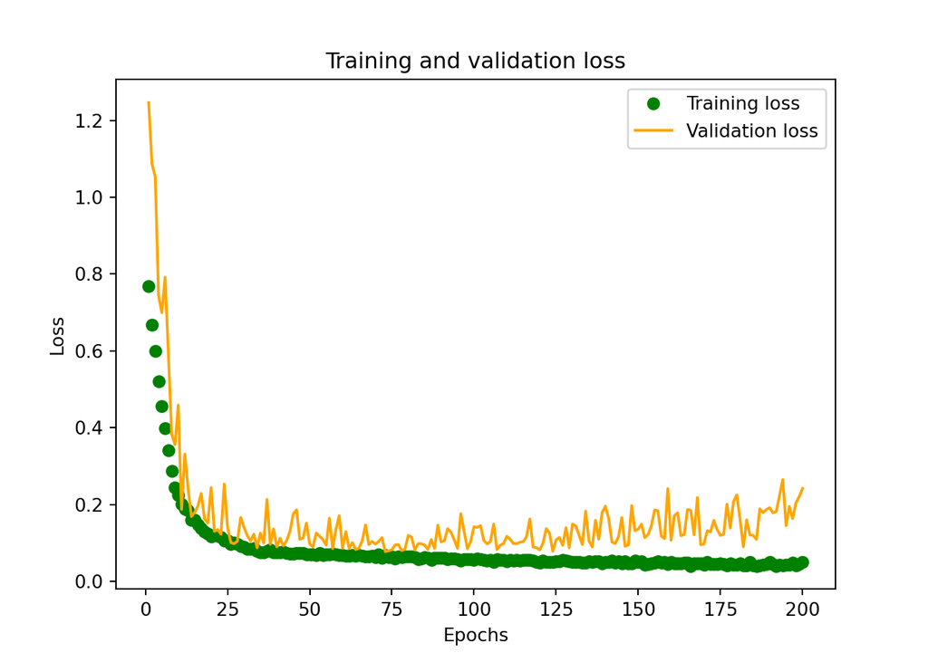

```
---------- Regression report ----------
TRAINING:
 RMSE: 0.20843116586156338
 MSE: 0.043443550902410547
 MAE: 0.16507024197453557
VALIDATION:
 RMSE: 0.4919828184199992
 MSE: 0.24204709362048588
 MAE: 0.38857506922467494
```

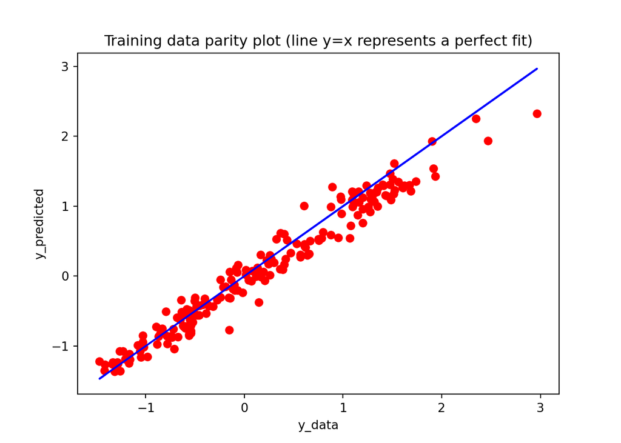

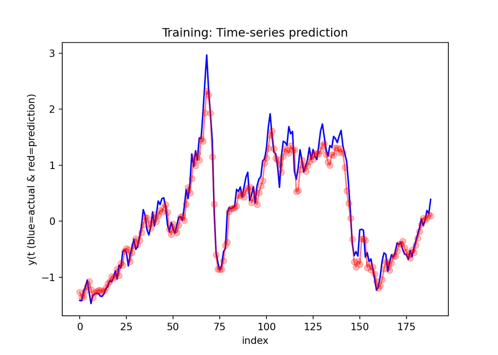

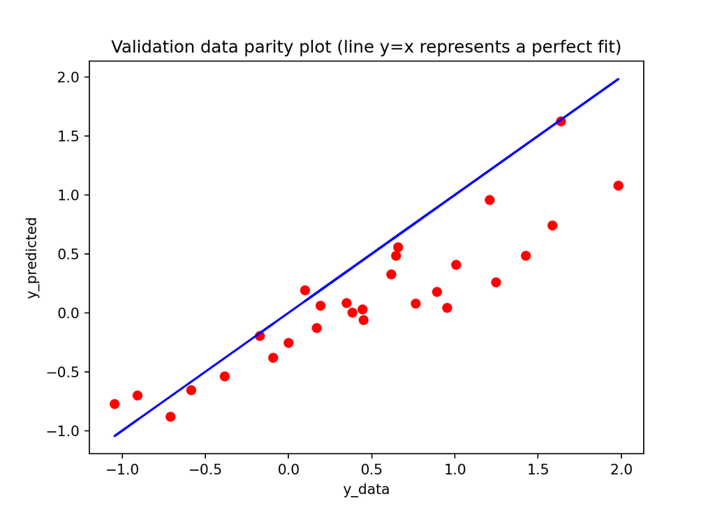

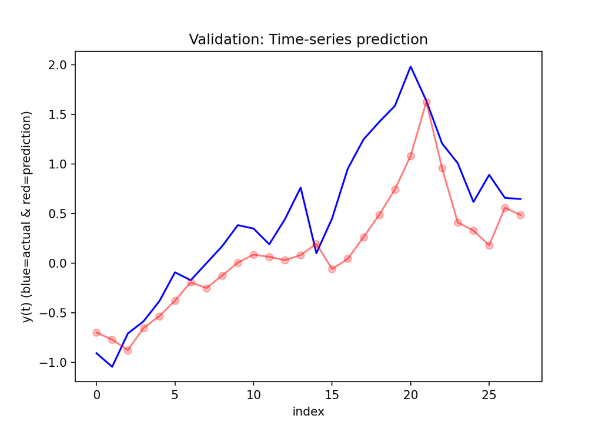

### Keras - LSTM

The last model created was LSTM, also obtained from the Keras package within Tensorflow.

By assessing the traning and validation loss plot, we can observe that this model is a midpoint between the two previously assessed. There is a los of fluctuation of the loss values but the value is still low. If we see more in detail we can clearly see that the trend is increasing. This suggests that with an increasing number of Epochs, for the higher values, the loss value in high.

When we compare the RMSE for the training set and the test set, we can see there is a high difference and the trend suggests it will increase.

The predictions observed in the Validation plots are kind of good, but these can change in the future forests. This model may tend to overfitting if we increase the number of points being forecasted.

```
(189, 26, 1) --> (189, 1)
```

```
(28, 26, 1) --> (28, 1)
```

```
Model: "sequential_2"
_________________________________________________________________
 Layer (type)                Output Shape              Param #
=================================================================
 lstm (LSTM)                 (None, 32)                4352

 dense_2 (Dense)             (None, 1)                 33

=================================================================
Total params: 4385 (17.13 KB)
Trainable params: 4385 (17.13 KB)
Non-trainable params: 0 (0.00 Byte)
_________________________________________________________________
None
```

```
WARNING:absl:At this time, the v2.11+ optimizer `tf.keras.optimizers.RMSprop` runs slowly on M1/M2 Macs, please use the legacy Keras optimizer instead, located at `tf.keras.optimizers.legacy.RMSprop`.
```

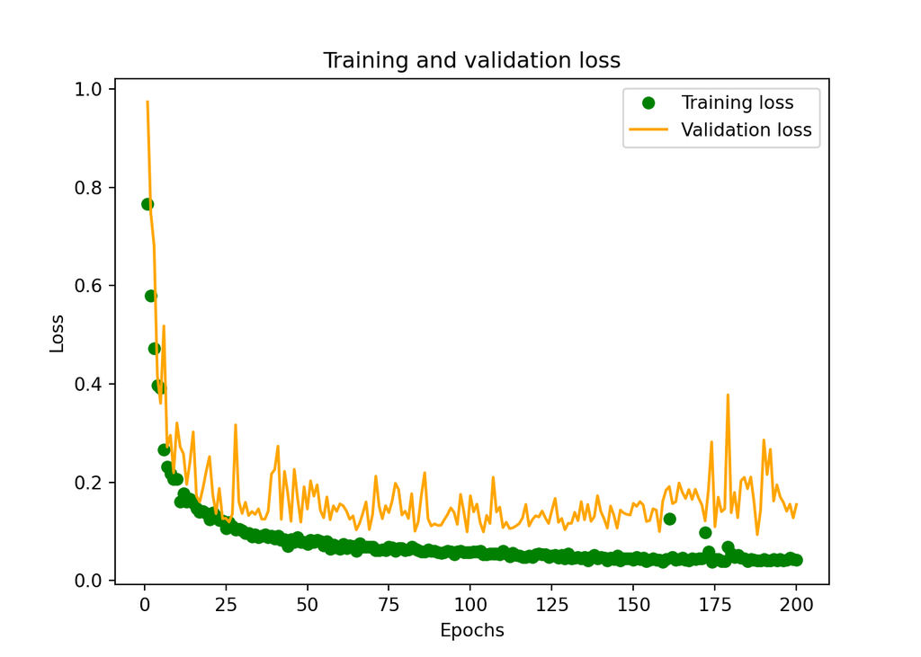

```
---------- Regression report ----------
TRAINING:
 RMSE: 0.188807104589032
 MSE: 0.03564812274329367
 MAE: 0.14501798502371144
VALIDATION:
 RMSE: 0.39370258511599426
 MSE: 0.15500172552701671
 MAE: 0.3231577125892908
```

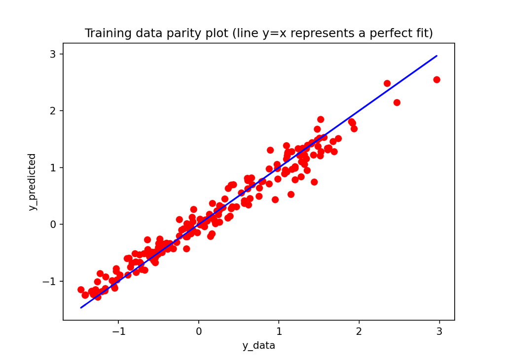

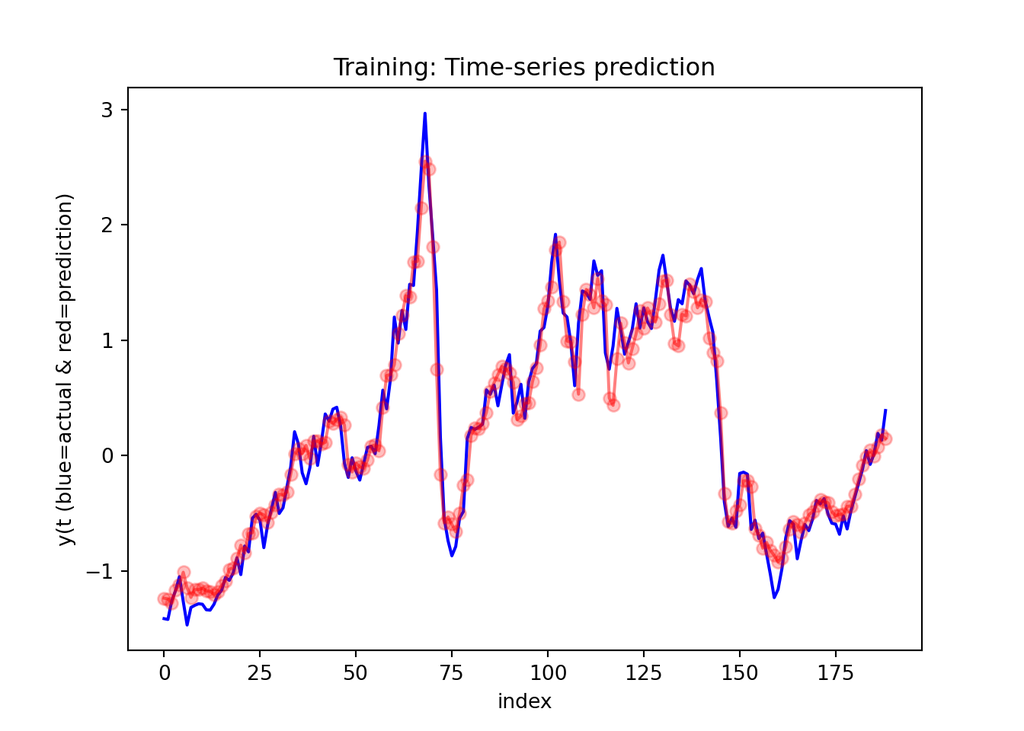

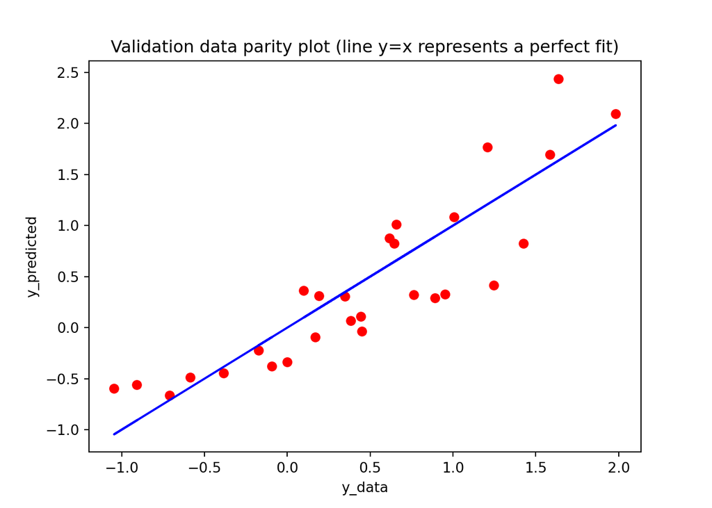

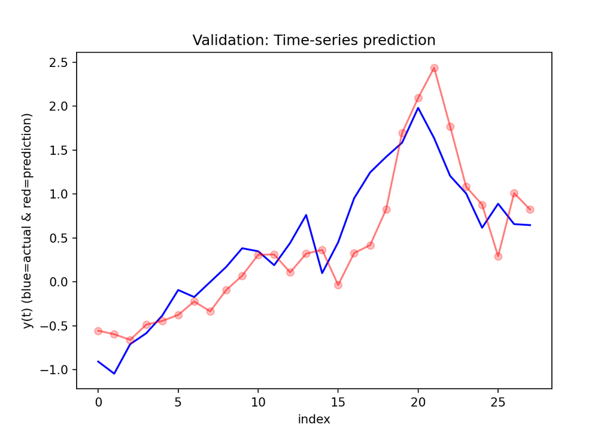

### Conclusions

As a conclusion, we need to evaluate the three models from different perspectives to undestand which model is performing better.

We modified the **regularization** parameter when training the models. This value was set by default in 0, which means there is no regularization at all. When we increase this value, the RMSE values are being higher compared to the default value. For that main reason, we decided to keep the regularization parameter as 0.

To assess how far into the future can the deep learning model accurately predict the future depends on the model that is being used. In terms of computationally intensive, with a lot of data points this predictions can take very long which that would not be very efficient. Also, as we have evaluated previously, for the LSTM model, the loss function, RMSE metric, was increasing over time, this suggests that the model was not accurately predicting the future values.

The deep learning models are very different to the ARIMA models. Tuning the deep learning models can be harder and more computationally intensive. On the other hand, the ARIMA model may take more steps to obtain the final model, but the analysis that has to be done is very similar to other models.